# Exercise Performance Prediction with Wearable Tech Data

Ayoub HAIDA

2023-12-20

## Background

With the increasing prevalence of wearable devices like Jawbone Up, Nike FuelBand, and Fitbit, the quantified self movement has gained momentum. This community of enthusiasts regularly collects personal activity data to enhance health, uncover behavioral patterns, or simply indulge their tech-savvy interests. While individuals often quantify the quantity of their activities, the evaluation of performance quality is frequently overlooked. In this project, our objective is to analyze data from accelerometers placed on the belt, forearm, arm, and dumbbell of six participants. These individuals were tasked with executing barbell lifts, both correctly and incorrectly, in five distinct manners. Detailed information is accessible on the website: http://groupware.les.inf.puc-rio.br/har (refer to the Weight Lifting Exercise Dataset section).

## The Data

The training and testing data for this project are available here:

- Training Data : https://d396qusza40orc.cloudfront.net/predmachlearn/pml-training.csv.
- Testing Data : https://d396qusza40orc.cloudfront.net/predmachlearn/pml-testing.csv.

The data for this project come from this source: http://groupware.les.inf.puc-rio.br/har.

# Loading Packages and Datasets

## Load necessary libraries

```r
library(data.table)
library(caret)
```

```r
library(ggplot2)
library(parallel)
library(doParallel)
library(visdat)
library(purrr)
library(dplyr)
library(printr)
library(corrplot)
library(kableExtra)
library(gbm)
library(e1071)
library(randomForest)
library(forecast)
```

## Check and load required libraries quietly.

```r
required_libraries <- c("data.table", "caret", "ggplot2", "parallel","doParallel",
                        "visdat", "purrr", "dplyr", "printr","corrplot",
                        "kableExtra", "gbm", "e1071", "randomForest","forecast")
library_check <- sapply(required_libraries, require, character.only = TRUE,
                        quietly = TRUE)
```

## Create a data directory if it doesn’t exist

```r
if (!file.exists("./data")) {
  dir.create("./data")
}
```

## Define the working directory and the URL for the datasets

```r
trainURL <- "https://d396qusza40orc.cloudfront.net/predmachlearn/pml-training.csv"
testURL <- "https://d396qusza40orc.cloudfront.net/predmachlearn/pml-testing.csv"
```

## Download the datasets

```r
# download.file(trainURL, file.path(path, "pml-training.csv"))
# download.file(testURL, file.path(path, "pml-testing.csv"))

trainData <- read.csv("./data/pml-training.csv")
testData <- read.csv("./data/pml-testing.csv")
```

First look at the data for each column and remove variables unrelated

```r
str(trainData)
```

```
## 'data.frame':    19622 obs. of  160 variables:
##  $ X                       : int  1 2 3 4 5 6 7 8 9 10 ...
##  $ user_name               : chr  "carlitos" "carlitos" "carlitos" "carlitos" ...
##  $ raw_timestamp_part_1    : int  1323084231 1323084231 1323084231 1323084232 1323084232 1323084232 1323084232 1323084232 1323084232 1323084232 ...
##  $ raw_timestamp_part_2    : int  788290 808298 820366 120339 196328 304277 368296 440390 484323 484434 ...
##  $ cvtd_timestamp          : chr  "05/12/2011 11:23" "05/12/2011 11:23" "05/12/2011 11:23" "05/12/2011 11:23" ...
##  $ new_window              : chr  "no" "no" "no" "no" ...
##  $ num_window              : int  11 11 11 12 12 12 12 12 12 12 ...
##  $ roll_belt               : num  1.41 1.41 1.42 1.48 1.48 1.45 1.42 1.42 1.43 1.45 ...
##  $ pitch_belt              : num  8.07 8.07 8.07 8.05 8.07 8.06 8.09 8.13 8.16 8.17 ...
##  $ yaw_belt                : num  -94.4 -94.4 -94.4 -94.4 -94.4 -94.4 -94.4 -94.4 -94.4 -94.4 ...
##  $ total_accel_belt        : int  3 3 3 3 3 3 3 3 3 3 ...
##  $ kurtosis_roll_belt      : chr  "" "" "" "" ...
##  $ kurtosis_picth_belt     : chr  "" "" "" "" ...
##  $ kurtosis_yaw_belt       : chr  "" "" "" "" ...
```

[output cut: 86 more lines]

```r
# subset the datasets
trainData <- trainData[, -c(1:7)]
testData <- testData[, -c(1:7)]
```

Let’s explore the dimensions of the underlying dataset

```r
# dimensions of the data
rbind(training = dim(trainData),
      testing = dim(testData))
```

| training | 19622 | 153 |
| --- | --- | --- |
| testing | 20 | 153 |

```r
set.seed(2023)
inTrain <- createDataPartition(y = trainData$classe, p = 0.7, list = F)
training <- trainData[inTrain, ]
testing <- trainData[-inTrain, ]
```

### Remove the variables with a lot of similarities

```r
nzv <- nearZeroVar(trainData, saveMetrics = T)
keepFeat <- row.names(nzv[nzv$nzv == FALSE, ])
training <- training[, keepFeat]
```

### Remove the variables with all NAs

```r
training <- training[, colSums(is.na(training)) == 0]
dim(training)
```

```
## [1] 13737    53
```

### Correlation

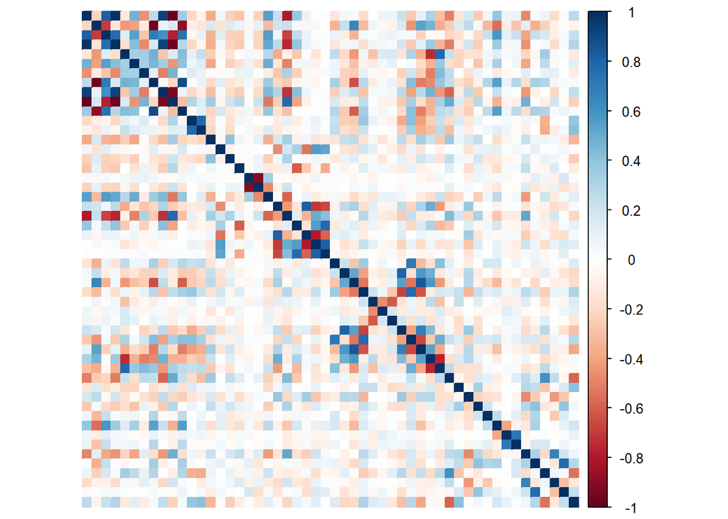

```r
corr_data <- select_if(training, is.numeric)
corrplot(
  cor(corr_data),
  method = "color",
  tl.pos = "n",
  insig = "blank"
)
```

## Model Training

### Set up 5-fold cross validation for training

```r
modCtl <- trainControl(method = 'cv', number = 5)
```

### Fit a model with random forests

```r
set.seed(2024)
#modRf <- train(classe ~. , data = training, method = 'rf', trControl = modCtl)
#saveRDS(modRf,file="modRf.rds")

modRf <- readRDS(file = "modRf.rds")
modRf
```

```
## Random Forest
##
## 13737 samples
##    52 predictor
##     5 classes: 'A', 'B', 'C', 'D', 'E'
##
## No pre-processing
## Resampling: Cross-Validated (5 fold)
## Summary of sample sizes: 10990, 10988, 10990, 10990, 10990
## Resampling results across tuning parameters:
##
##   mtry  Accuracy   Kappa
##    2    0.9907548  0.9883032
##   27    0.9909732  0.9885806
##   52    0.9848583  0.9808446
##
## Accuracy was used to select the optimal model using the largest value.
## The final value used for the model was mtry = 27.
```

- Read the summary of the model built with random forests

```r
modRf$finalModel
```

```
##
## Call:
##  randomForest(x = x, y = y, mtry = param$mtry)
##                Type of random forest: classification
##                      Number of trees: 500
## No. of variables tried at each split: 27
##
##         OOB estimate of  error rate: 0.67%
## Confusion matrix:
##      A    B    C    D    E class.error
## A 3901    3    2    0    0 0.001280082
## B   23 2630    5    0    0 0.010534236
## C    0   11 2376    9    0 0.008347245
## D    0    1   25 2223    3 0.012877442
## E    0    2    4    4 2515 0.003960396
```

- Plot the Losses.

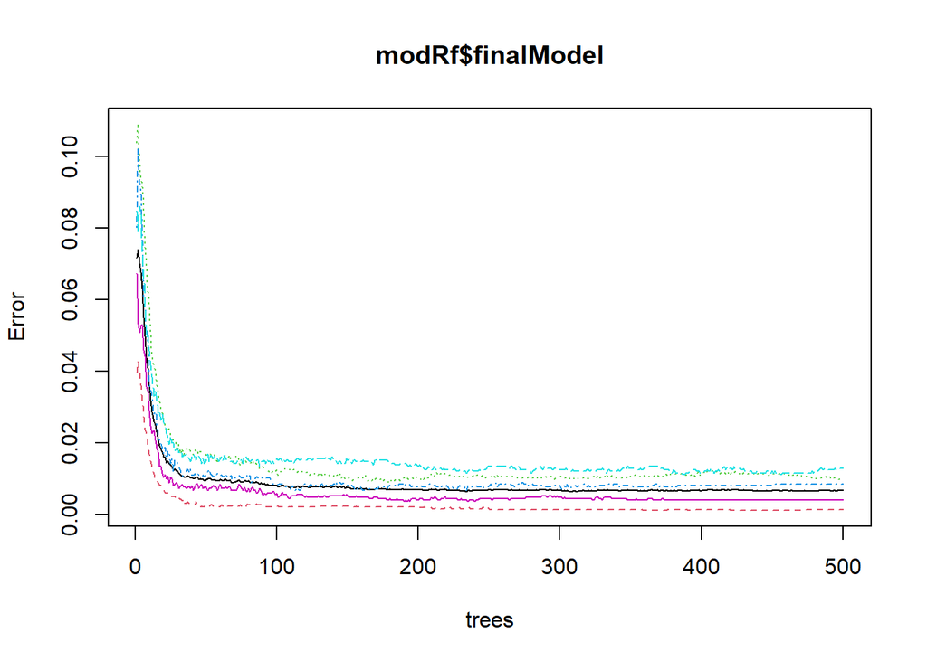

```r
plot(modRf$finalModel)
```

- List the important features (Top 10)

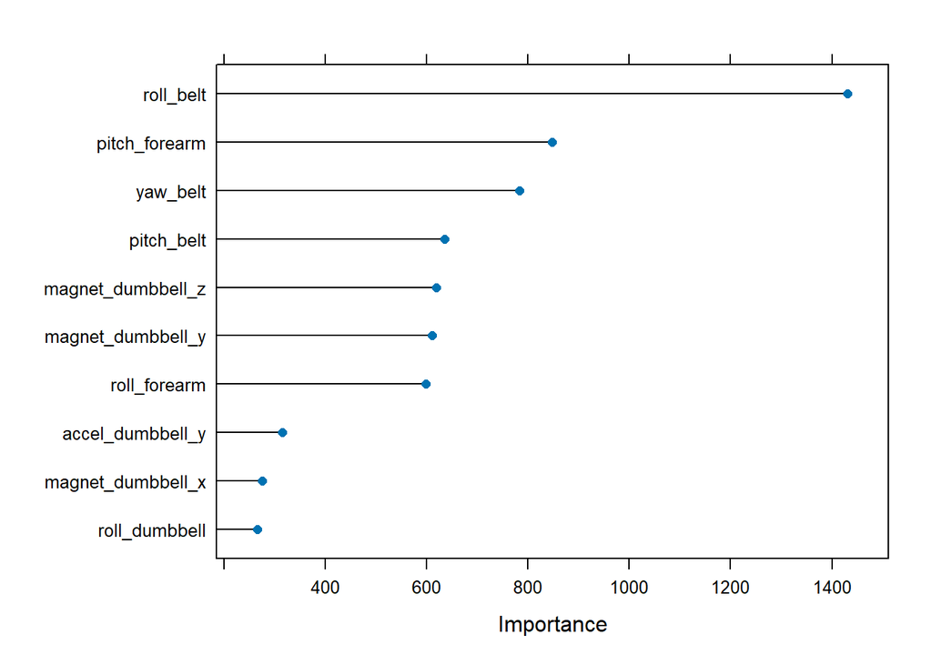

```r
importance <- varImp(modRf, scale = FALSE)
plot(importance, top=10)
```

- Predict with the validation set and check the confusion matrix and accuracy

```r
pred.rf <- predict(modRf, testing)
testing$classe <- factor(testing$classe, levels =
                           c("A", "B", "C", "D", "E"))
confusionMatrix(pred.rf, testing$classe)$table
```

|  | A | B | C | D | E |
| --- | --- | --- | --- | --- | --- |
| A | 1671 | 5 | 0 | 0 | 0 |
| B | 2 | 1133 | 3 | 1 | 1 |
| C | 0 | 1 | 1021 | 8 | 2 |
| D | 0 | 0 | 2 | 951 | 0 |
| E | 1 | 0 | 0 | 4 | 1079 |

```r
confusionMatrix(pred.rf, testing$classe)$overall[1]
```

```
##  Accuracy
## 0.9949023
```

### Fit a model with gradient boosting method.

```r
#modGbm <- train(classe ~., data = training, method = 'gbm', trControl = modCtl, verbose = F)
#saveRDS(modGbm ,file="modGbm .rds")

modGbm  <- readRDS(file = "modGbm .rds")
modGbm
```

```
## Stochastic Gradient Boosting
##
## 13737 samples
##    52 predictor
##     5 classes: 'A', 'B', 'C', 'D', 'E'
##
## No pre-processing
## Resampling: Cross-Validated (5 fold)
## Summary of sample sizes: 10990, 10990, 10990, 10989, 10989
## Resampling results across tuning parameters:
##
##   interaction.depth  n.trees  Accuracy   Kappa
##   1                   50      0.7567156  0.6915006
##   1                  100      0.8199759  0.7721977
##   1                  150      0.8519330  0.8126523
##   2                   50      0.8543350  0.8154923
##   2                  100      0.9066029  0.8817842
##   2                  150      0.9320085  0.9139597
##   3                   50      0.8951737  0.8672749
##   3                  100      0.9429281  0.9277804
##   3                  150      0.9606172  0.9501778
##
## Tuning parameter 'shrinkage' was held constant at a value of 0.1
##
## Tuning parameter 'n.minobsinnode' was held constant at a value of 10
## Accuracy was used to select the optimal model using the largest value.
## The final values used for the model were n.trees = 150, interaction.depth =
##  3, shrinkage = 0.1 and n.minobsinnode = 10.
```

- Read the summary of the model built with gbm

```r
modGbm$finalModel
```

```
## A gradient boosted model with multinomial loss function.
## 150 iterations were performed.
## There were 52 predictors of which 52 had non-zero influence.
```

- Predict with the validation set and check the confusion matrix and accuracy

```r
predGbm <- predict(modGbm, newdata = testing)
confusionMatrix(predGbm, testing$classe)$table
```

|  | A | B | C | D | E |
| --- | --- | --- | --- | --- | --- |
| A | 1649 | 52 | 0 | 0 | 1 |
| B | 14 | 1051 | 24 | 2 | 9 |
| C | 9 | 35 | 988 | 32 | 11 |
| D | 2 | 1 | 12 | 920 | 11 |
| E | 0 | 0 | 2 | 10 | 1050 |

```r
confusionMatrix(predGbm, testing$classe)$overall[1]
```

```
##  Accuracy
## 0.9614274
```

## Test the two models on the new test dataset

### The first model (Random Forest)

```r
predRfTest <- predict(modRf, newdata = testData)
predRfTest
```

```
##  [1] B A B A A E D B A A B C B A E E A B B B
## Levels: A B C D E
```

### The second model (Gradient Boosting Method)

```r
predGbmTest <- predict(modGbm, newdata = testData)
predGbmTest
```

```
##  [1] B A B A A E D B A A B C B A E E A B B B
## Levels: A B C D E
```

### Comparison

```r
table(predRfTest, predGbmTest)
```

|  | A | B | C | D | E |
| --- | --- | --- | --- | --- | --- |
| A | 7 | 0 | 0 | 0 | 0 |
| B | 0 | 8 | 0 | 0 | 0 |
| C | 0 | 0 | 1 | 0 | 0 |
| D | 0 | 0 | 0 | 1 | 0 |
| E | 0 | 0 | 0 | 0 | 3 |

The two models produce almost the same results, as shown in the confusion matrix above.